# TU060 - Math 9102 – PSI - Portfolio - Model - Logistic

Joseph O’Carroll

20/12/2020

# Logistic Regression

In linear regression, our outcome variable is continuous and is predicted from one or more continuous or categorical predictor variables. If the outcomes we are interested in are categorical in nature, we cannot use linear regression as there is no linear relationship between predictor and outcomes variables. To predict categorical outcomes, we use logistic regression. If the outcome variable has exactly two values, for example predicting pass or fail for a student, we use a binary logistic regression. When the outcome has more than two categories, we use a multi-nominal logistic regression. The output from a logistic regression is not an estimated value but rather a probability that the given input belongs to a certain category or not. Because we’re looking at probability, we choose one category as the category of interest. The event we’re interested in is the event where that category occurs. The reference event is when the event of interest doesn’t occur and we are interested in the probability of the event of interest occurring versus the probability of it not occurring.

## Binary Logistic Regression

To illustrate this methodology we will make use of the student performance data set to build a model to predict if students sat the final maths examination, using gender as the predictor.

> HA: Gender is a factor in determining if a student will sit the final maths examination

Note: We’re building a model with one predictor to illustrate our understanding of how logistic regression works. The starting point is a simple logistic regression, which we will build upon. We gain no new insights from this over and above a difference test.

### Step 1: Run Simple Logistic Regression

```
##
## Call:
## glm(formula = tbl_sperf_sex_medu_diff$sat_maths ~ tbl_sperf_sex_medu_diff$sex,
##     family = binomial(link = logit), data = tbl_sperf_sex_medu_diff,
##     na.action = na.exclude)
##
## Deviance Residuals:
##     Min       1Q   Median       3Q      Max
## -2.2101   0.4265   0.4265   0.4970   0.4970
##
## Coefficients:
##                              Estimate Std. Error z value Pr(>|z|)
## (Intercept)                    2.0293     0.2218   9.149   <2e-16 ***
## tbl_sperf_sex_medu_diff$sexM   0.3221     0.3430   0.939    0.348
## ---
## Signif. codes:  0 '***' 0.001 '**' 0.01 '*' 0.05 '.' 0.1 ' ' 1
##
## (Dispersion parameter for binomial family taken to be 1)
##
##     Null deviance: 251.86  on 381  degrees of freedom
## Residual deviance: 250.97  on 380  degrees of freedom
## AIC: 254.97
##
## Number of Fisher Scoring iterations: 5
```

|  | #Df | LogLik | Df | Chisq | Pr(>Chisq) |
| --- | --- | --- | --- | --- | --- |
| 1 | 2 | -125.4838 | NA | NA | NA |
| 2 | 1 | -125.9302 | -1 | 0.8929079 | 0.3446905 |

### Step 2: Calculate odds ratio and probability

Summary of co-efficients

|  | Estimate | Odds_ratio | Probability |
| --- | --- | --- | --- |
| (Intercept) | 2.0293 | 7.6087 | 0.8838384 |
| tbl_sperf_sex_medu_diff$sexM | 0.3221 | 1.3800 | 0.9130435 |

### Step 3: Check goodness of fit of the model over the baseline model

In linear regression we check goodness of fit by comparing our results to the results we would have gotten using the mean as the baseline model. For logistic regression an omnibus test is used to check that the new model (with explanatory variables included) is an improvement over the baseline model which is a sum of frequencies of occurrence of each category. We use chi-square tests to see if there is a significant difference between the baseline model (null) and the model we have created.

Below we can see our model is not statistically significant (Pr(>Chisq) = 0.3447), which means it cannot be assumed to be a better predictor than the baseline model. This was not surprising since our predictor variable (sex) was shown to not be statistically significant.

Summary statistics for regression compared to baselien model

| #Df | LogLik | Df | Chisq | Pr(>Chisq) |
| --- | --- | --- | --- | --- |
| 2 | -125.4838 | NA | NA | NA |
| 1 | -125.9302 | -1 | 0.8929079 | 0.3446905 |

### Step 4: Determine usefulness

We can get a pseudo R squared value to determine how useful the model is. From linear regression we understood the R2 was a measure of how much of the outcome variable was explained by the predictor variable. Cox and Snell R2 and Nagelkerke R2 are pseudo R2 statistics we can generate. From this we see that student sex explains between 0.2% and 0.48% of whether a student will sit the final maths exam or not, but we need to keep in mind the result was not statistically significant.

Summary of Pseudo R-Squared values

|  | CoxSnell | Nagelkerke |
| --- | --- | --- |
| R-Squared | 0.0023 | 0.0048 |

### Step 5: Sensitivity Analysis and Summary Stats.

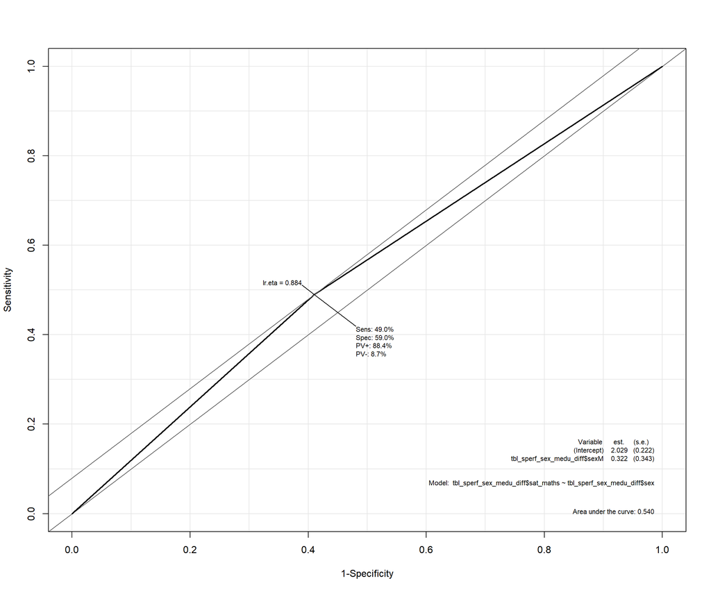

### Step 6: Check the assumption of linearity of independent variables

We only have one predictor so we don’t need to check for collinearity. We check the assumption of linearity of independent variables and log odds using a Hosmer-Lemeshow test.

```
##
##  Hosmer and Lemeshow test (binary model)
##
## data:  tbl_sperf_sex_medu_diff$sat_maths, fitted(logmodel1)
## X-squared = 5.6128e-26, df = -1, p-value = NA
```

### Reporting Binary Logistic Regression

A Binary logistic regression model was built of student propensity to sit the final Maths examination as predicted by student sex. Our outcome variable is the probability of a student sitting the final Maths exam given their gender. As such, we give zero to the “no” category, which is our reference category, and 1 to our category of interest which is “yes” they did sit the exam. For our predictor we used sex, with values Male and Female. Being Male was not found to be a statistically significant ( P = .348 ) predictor of whether a student will or will not not sit the examination. Female Students have an odd ratio of 7.60 to 1 to sit the exam while Male student odds where 1.38 higher which corresponds to a probability of .88 and .91 respectively. R2 = .0023 (Cox-Snell), .0048 (Nagelkerke), Pr (>Chisq) = .34.

```
##
## =============================================
##                       Dependent variable:
##                   ---------------------------
##                            sat_maths
## ---------------------------------------------
## sexM                         0.322
##                             (0.343)
##
## Constant                   2.029***
##                             (0.222)
##
## ---------------------------------------------
## Observations                  382
## Log Likelihood             -125.484
## Akaike Inf. Crit.           254.968
## =============================================
## Note:             *p<0.1; **p<0.05; ***p<0.01
```

## Extra: Extending the model to include Parent’s Education.

Similar to Linear regression we can extend logistic regression to include multiple predictors. Our goal is to explore if we can predict if a student will sit the final Maths exam on the basis of their parents’ education. We introduce a new categorical variable representing the highest educational achievement of either parent. We have 3 levels: at least one parent with a higher degree, at least one parent with a level 5 qualification (secondary school) and neither parent with a level 5 qualification. At least one parent with a higher degree was taken as the baseline reference category.

### Step 1: Run General Logistic Regression

We find that the overall model is not statistically significant (Pr(>Chisq) = .077) but the category *Neither parent with a level 5 qualification* is statistically significant at the P <0.05 significances level.

```
##
## Call:
## glm(formula = sat_maths ~ sex + pedu_paired, family = binomial(link = logit),
##     data = tbl_sperf_sex_medu_diff, na.action = na.exclude)
##
## Deviance Residuals:
##     Min       1Q   Median       3Q      Max
## -2.3552   0.3708   0.4099   0.5458   0.6193
##
## Coefficients:
##                                                              Estimate
## (Intercept)                                                   2.36843
## sexM                                                          0.27464
## pedu_paired At least one parent with a level 5 qualification  0.06604
## pedu_paired Neither parent with a level 5 qualification      -0.81430
##                                                              Std. Error z value
## (Intercept)                                                     0.34178   6.930
## sexM                                                            0.34668   0.792
## pedu_paired At least one parent with a level 5 qualification    0.49488   0.133
## pedu_paired Neither parent with a level 5 qualification         0.38806  -2.098
##                                                              Pr(>|z|)
## (Intercept)                                                  4.22e-12 ***
## sexM                                                           0.4283
## pedu_paired At least one parent with a level 5 qualification   0.8938
## pedu_paired Neither parent with a level 5 qualification        0.0359 *
## ---
## Signif. codes:  0 '***' 0.001 '**' 0.01 '*' 0.05 '.' 0.1 ' ' 1
##
## (Dispersion parameter for binomial family taken to be 1)
##
##     Null deviance: 251.86  on 381  degrees of freedom
## Residual deviance: 245.00  on 378  degrees of freedom
## AIC: 253
##
## Number of Fisher Scoring iterations: 5
```

|  | #Df | LogLik | Df | Chisq | Pr(>Chisq) |
| --- | --- | --- | --- | --- | --- |
| 1 | 4 | -122.5014 | NA | NA | NA |
| 2 | 1 | -125.9302 | -3 | 6.857641 | 0.07657636 |

### Step 2: Calculate odds ratio and probability

Student sex remained a statistically insignificant variable. The only level of parental educational achievement that was significant was if neither parent had a level 5 education.

Summary of co-efficients

|  | Estimate | Odds_ratio |
| --- | --- | --- |
| (Intercept) | 2.3684 | 10.6806 |
| sexM | 0.2746 | 1.3161 |
| pedu_paired At least one parent with a level 5 qualification | 0.0660 | 1.0683 |
| pedu_paired Neither parent with a level 5 qualification | -0.8143 | 0.4430 |

Summary of co-efficients probabilities

|  | X.Intercept. |
| --- | --- |
| Female | 0.91 |
| Male | 0.93 |
| Female_level5 | 0.92 |
| Male_level5 | 0.94 |
| Female_nolevel5 | 0.83 |
| Male_nolevel5 | 0.86 |

```
## Predicted levels same as naive model (majority level)
```

Confusion Matrix

|  | Predicted 1 |
| --- | --- |
| Actual 0 | 39 |
| Actual 1 | 343 |

### Step 3: Check goodness of fit of the model over the baseline model

Summary statistics for regression compared to baselien model

| #Df | LogLik | Df | Chisq | Pr(>Chisq) |
| --- | --- | --- | --- | --- |
| 4 | -122.5014 | NA | NA | NA |
| 1 | -125.9302 | -3 | 6.85764 | 0.0765764 |

### Step 4: Determine usefulness

The Pseudo R squared statistics show that our extended model explains between 1.78% and 3.69% of the variation in the outcome variable. This is consistent with our findings above.

Summary of Pseudo R-Squared values

|  | CoxSnell | Nagelkerke |
| --- | --- | --- |
| R-Squared | 0.0178 | 0.0369 |

### Step 5: Sensitivity Analysis and Summary Stats.

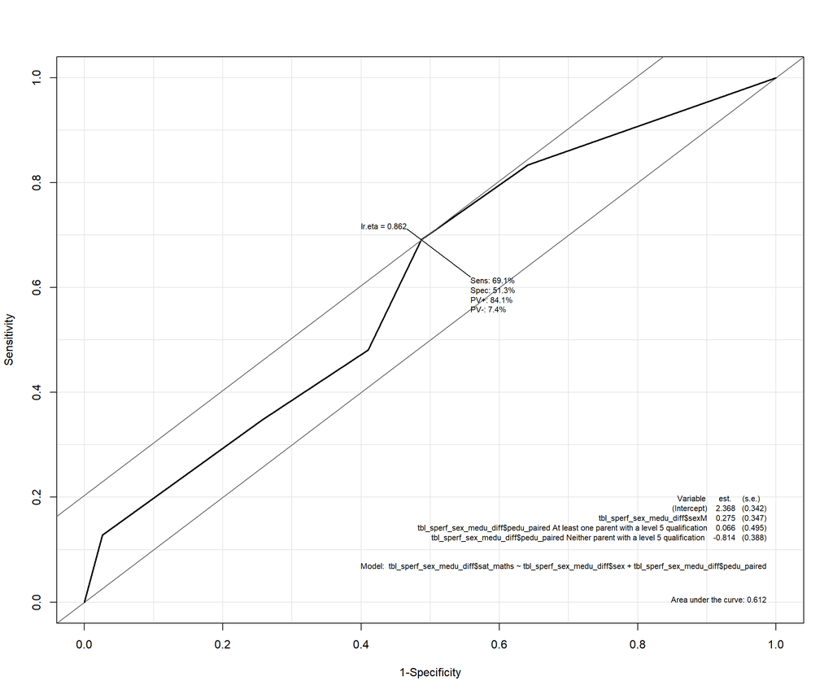

### Step 6: Check the assumption of linearity of independent variables

We have two predictor variables so we need to check for collinearity. Conceptually, student sex and parental educational achievement should not be collinear, but the step is included for illustration. We check the assumption of linearity of independent variables and log odds using a Hosmer-Lemeshow test.

```
##
##  Hosmer and Lemeshow test (binary model)
##
## data:  tbl_sperf_sex_medu_diff$sat_maths, fitted(logmodel2)
## X-squared = 6.3334, df = 3, p-value = 0.09647
```

```
##                 GVIF Df GVIF^(1/(2*Df))
## sex         1.005222  1        1.002608
## pedu_paired 1.005222  2        1.001303
```

```
##                  GVIF  Df GVIF^(1/(2*Df))
## sex         0.9948052 1.0       0.9973992
## pedu_paired 0.9948052 0.5       0.9986988
```

## Multinomial logistic regression

We can also use logistic regression to predict if a case will be a member of more than two categories. To illustrate this methodology, we will make use of the student performance data set to build a model to predict student alcohol consumption on the basis of performance.

> HA: Subject performance, failures, and absences are good predictors of student tendency to consume alcohol

### Step 1: Quick summary of the data

A general guideline is that we need a minimum of 10 cases with the least frequent value for each categorical variable in our model. A quick look at the data shows we meet this requirement.

Summary of Weekend Alchol Consumption (Walc.p)

|  | Freq | % Valid | % Valid Cum. | % Total | % Total Cum. |
| --- | --- | --- | --- | --- | --- |
| 1 | 144 | 37.696335 | 37.69634 | 37.696335 | 37.69634 |
| 2 | 86 | 22.513089 | 60.20942 | 22.513089 | 60.20942 |
| 3 | 76 | 19.895288 | 80.10471 | 19.895288 | 80.10471 |
| 4 | 49 | 12.827225 | 92.93194 | 12.827225 | 92.93194 |
| 5 | 27 | 7.068063 | 100.00000 | 7.068063 | 100.00000 |
| <NA> | 0 | NA | NA | 0.000000 | 100.00000 |
| Total | 382 | 100.000000 | 100.00000 | 100.000000 | 100.00000 |

Summary of Student Failures (failures.p)

|  | n | median | mad | min | max | range | skew | kurtosis | se |
| --- | --- | --- | --- | --- | --- | --- | --- | --- | --- |
| X1 | 382 | 0 | 0 | 0 | 3 | 3 | 4.150294 | 17.77067 | 0.0262603 |

Summary of Student Absences (absences.p)

|  | n | median | mad | min | max | range | skew | kurtosis | se |
| --- | --- | --- | --- | --- | --- | --- | --- | --- | --- |
| X1 | 382 | 2 | 2.9652 | 0 | 32 | 32 | 2.165519 | 6.17826 | 0.251011 |

### Step 2: Run Multi-nominal Logistic Regression

```
##         Walc.p
## famrel.p  1  2  3  4  5
##        1  2  3  1  0  2
##        2  6  3  3  4  2
##        3 19 16 14 13  5
##        4 71 39 41 21 12
##        5 46 25 17 11  6
```

```
##          M       SD
## 1 13.13194 2.430133
## 2 12.68605 2.963550
## 3 12.36842 3.281634
## 4 11.48980 2.731929
## 5 10.96296 3.787444
```

```
##            M        SD
## 0  12.720000 3.4740070
## 1  14.333333 1.5275252
## 2  12.984615 2.3617546
## 3   8.500000 2.1213203
## 4  12.393443 2.4985242
## 6  12.657895 1.9765697
## 7  15.500000 0.7071068
## 8  12.263158 2.4909192
## 9  10.000000        NA
## 10 12.555556 3.0867099
## 12 10.428571 3.2586880
## 14 11.333333 3.0110906
## 15 11.000000 1.4142136
## 16 10.000000 1.7320508
## 18 13.500000 0.7071068
## 21 13.000000        NA
## 22  7.333333 2.3094011
## 30 16.000000        NA
## 32 14.000000        NA
```

```
## Call:
## multinom(formula = Walc.p ~ absences.p + pG3, data = tbl_sperf_family_alc)
##
## Coefficients:
##   (Intercept) absences.p         pG3
## 2  0.01087414 0.04400762 -0.05210308
## 3  0.49526196 0.02913020 -0.09622110
## 4  0.96253579 0.06192398 -0.18320827
## 5  0.66035020 0.09538812 -0.22493513
##
## Std. Errors:
##   (Intercept) absences.p        pG3
## 2   0.7013638 0.03074781 0.05172324
## 3   0.7022372 0.03279891 0.05249118
## 4   0.7414868 0.03397290 0.05753070
## 5   0.8471884 0.03716125 0.06793020
##
## Residual Deviance: 1099.773
## AIC: 1123.773
```

Summary of Predictor Probability Pr(>|z|)

|  | (Intercept) | absences.p | pG3 |
| --- | --- | --- | --- |
| 2 | 0.9876299 | 0.1523603 | 0.3137696 |
| 3 | 0.4806466 | 0.3744626 | 0.0667891 |
| 4 | 0.1942475 | 0.0683418 | 0.0014499 |
| 5 | 0.4357083 | 0.0102621 | 0.0009287 |

|  | #Df | LogLik | Df | Chisq | Pr(>Chisq) |
| --- | --- | --- | --- | --- | --- |
| 1 | 12 | -549.8867 | NA | NA | NA |
| 2 | 4 | -563.6012 | -8 | 27.42896 | 0.000595945 |

### Step 2: Calculate odds ratio and probability

Summary of co-efficients (Odds Ratios)

|  | X.Intercept. | absences.p | pG3 |
| --- | --- | --- | --- |
| 2 | 1.0109 | 1.0450 | 0.9492 |
| 3 | 1.6409 | 1.0296 | 0.9083 |
| 4 | 2.6183 | 1.0639 | 0.8326 |
| 5 | 1.9355 | 1.1001 | 0.7986 |

|  | absences.p | pG3 | variable | probability |
| --- | --- | --- | --- | --- |
| 1 | 0 | 0 | 1 | 0.1218671 |
| 2 | 1 | 1 | 1 | 0.1323312 |
| 3 | 2 | 2 | 1 | 0.1433149 |
| 4 | 3 | 3 | 1 | 0.1547898 |
| 5 | 4 | 4 | 1 | 0.1667205 |
| 6 | 5 | 5 | 1 | 0.1790644 |

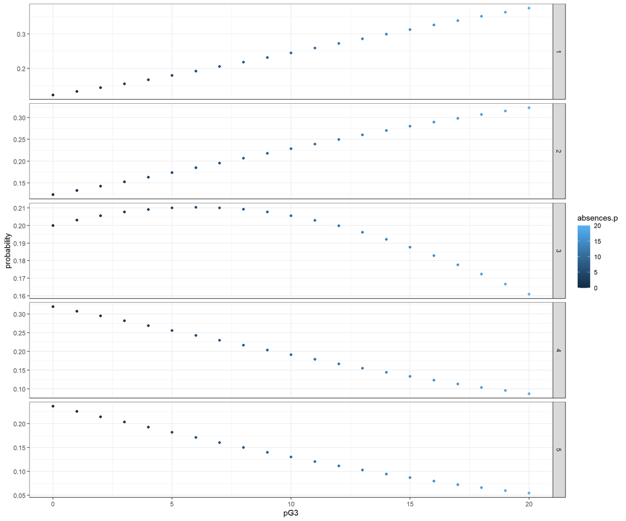

### Step 4: Check goodness of fit of the model over the baseline model

Below we can see our model is statistically significant (Pr(>Chisq) < .001), which means it can be assumed to be better than the baseline.

Summary statistics for regression compared to baselien model

| #Df | LogLik | Df | Chisq | Pr(>Chisq) |
| --- | --- | --- | --- | --- |
| 12 | -549.8867 | NA | NA | NA |
| 4 | -563.6012 | -8 | 27.42896 | 0.0005959 |

### Step 5: Determine usefulness

The Pseudo R squared statistics show that our extended model explains between 6.93% and 7.31% of the variation in the outcome variable. This is consistent with our findings above.

Summary of Pseudo R-Squared values

|  | CoxSnell | Nagelkerke |
| --- | --- | --- |
| R-Squared | 0.0693 | 0.0731 |

### Step 6: Check the assumption of linearity of independent variables

We checked the assumption of linearity of independent variables and log odds using a Hosmer-Lemeshow test and found it was not statistically significant. Multicollinearity analysis showed that the tolerance and variance influence factor measures were not within acceptable levels (tolerance >0.4, VIF <2.5 ) as outlined in Tarling (2008). As such we may have problems with collinearity.

```
##
##  Hosmer and Lemeshow test (multinomial model)
##
## data:  tbl_sperf_family_alc$Walc.p, fitted(logmodel3)
## X-squared = 34.594, df = 32, p-value = 0.345
```

Multi colinearity Tolerance

|  | VIF.Tolerance | vifmodel |
| --- | --- | --- |
| absences.p | 0.4075424 | 2.453733 |
| pG3 | 0.0335390 | 29.816033 |

### Reporting Multinominal Logistic Regression

A Multinomial logistic regression model of student Alcohol consumption as predicted by student performance and absenteeism was built. Our outcome variable is the probability of a student having each of the alcohol consumption levels given their performance and absenteeism rates. Our reference outcome category was level 1, very low consumption. For our predictor, we used student performance and absence from Portuguese class. The model was statistically significant (Pr(>Chisq) = .001 ) and explains between 6.93% and 7.31% of the variation in the output variable. The level of collinearity between predictors was outside the acceptable range, however.

```
##
## =========================================================
##                             Dependent variable:
##                   ---------------------------------------
##                       2         3         4         5
##                      (1)       (2)       (3)       (4)
## ---------------------------------------------------------
## absences.p          0.044     0.029    0.062*    0.095**
##                    (0.031)   (0.033)   (0.034)   (0.037)
##
## pG3                -0.052    -0.096*  -0.183*** -0.225***
##                    (0.052)   (0.052)   (0.058)   (0.068)
##
## Constant            0.011     0.495     0.963     0.660
##                    (0.701)   (0.702)   (0.741)   (0.847)
##
## ---------------------------------------------------------
## Akaike Inf. Crit. 1,123.773 1,123.773 1,123.773 1,123.773
## =========================================================
## Note:                         *p<0.1; **p<0.05; ***p<0.01
```